# Attainment and Attendance in Hastings

What the national model behind *How to Pull the Right Lever* says about the district’s secondary schools, within East Sussex and alongside Brighton and Hove. **Draft for discussion.**

Author

Affiliation

Adam Dennett

Bartlett Centre for Advanced Spatial Analysis, University College London

Published

October 31, 2026

**WarningDraft for discussion**

One of the district documents for Sussex. It sits beneath the East Sussex document, and the district summary compares all of the districts. Every figure comes from published Department for Education data and the national models of [How to Pull the Right Lever](https://adamdennett.github.io/school_attainment_tool/pulling_the_right_lever_v2.html). Nothing uses pupil-level records. The commentary is written to a common pattern from the figures; read it as a starting point for discussion.

# Summary

**Hastings’s results are among the weakest of England’s districts, on an intake more disadvantaged than England’s.** Its 3 state secondary schools are in Hastings and St Leonards-on-Sea.

The other findings:

- **For all pupils, Hastings is 11.4 points below England.** The largest pieces in the national model are absence (-3.9) and Ofsted ratings (-1.9). The district’s schools take 4.5 points beyond what the model expects.
- **For disadvantaged pupils it is 10.6 points below England.** The largest pieces are absence (-4.5) and Ofsted ratings (-1.8), and the schools take 3.7 points beyond what the model expects.
- **A district effect on the published model disappears once each school’s own record is counted.** On the published model Hastings differs from the rest of East Sussex for all pupils (-4.4%), non-disadvantaged pupils (-3.9%) and absence (+9.9%), but that difference belongs to particular schools, not to the place.
- **None of the 3 schools is above expectation** over 2021/22 to 2024/25. The strongest is Ark Alexandra Academy (-1.9); the weakest The St Leonards Academy (-5.3).
- **Absence was 7.0%** in autumn and spring 2025/26 (10.0% a year earlier), against 8.0% for England and 8.9% for East Sussex. Over 2021/22 to 2024/25 its schools ran 2.8 points above what their intakes predict, and The Hastings Academy and The St Leonards Academy more than a point above.
- **Reduced timetables run at 0.4 times the national rate, and suspensions at 3.7 times** (77.8 per 100 pupils, against 21.2).
- **Disadvantaged groups are small,** 50 to 101 pupils a year per school. Every school-level figure for them moves from year to year and should be read over several years.

# 1 About this analysis

The methods are described in full in the East Sussex document.

# 2 The district’s schools

[interactive chart not shown]

Hastings’s state-funded secondary schools, coloured by overall absence in 2024/25. Choose another measure from the menu above the map; circle size is the school’s roll. Hover for figures and who runs each school.

Every state-funded secondary school in the district, 2024/25, with the size of its disadvantaged Year 11 group.

| School | Town | Type | Pupils | FSM % | Disadvantaged in Year 11 | Absence % | KS2 | Att 8 | Att 8 disadv. | Ofsted |
| --- | --- | --- | --- | --- | --- | --- | --- | --- | --- | --- |
| Ark Alexandra Academy | Hastings | Academy | 1431 | 32.1 | 71 | 8.9 | 4.1 | 42.4 | 34.3 | Requires Improvement |
| The Hastings Academy | Hastings | Academy | 808 | 33.8 | 50 | 10.2 | 4.4 | 38.0 | 28.4 | Requires Improvement |
| The St Leonards Academy | St Leonards-on-Sea | Academy | 1322 | 39.3 | 101 | 11.1 | 2.7 | 33.1 | 25.7 | Requires Improvement |

None of the 3 schools is maintained by East Sussex County Council. The academies are run as follows:

- **Ark Alexandra Academy**, in Ark Schools (sponsored);
- **The Hastings Academy**, in University of Brighton Academies Trust (sponsored); it moved to Mulberry Schools Trust after 2024/25;
- **The St Leonards Academy**, in University of Brighton Academies Trust (sponsored); it moved to Mulberry Schools Trust after 2024/25;

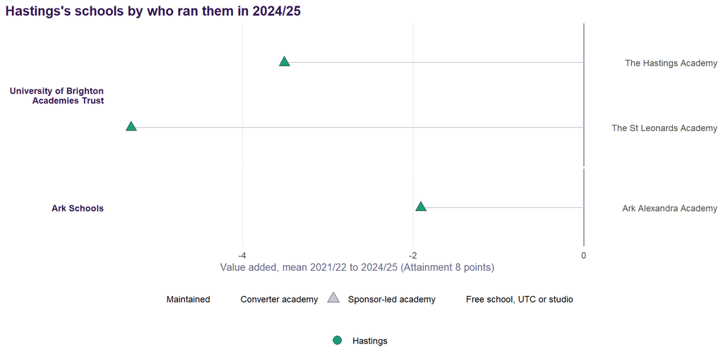

Figure 1: Who ran each school in 2024/25, and how far its results sat above or below the national model’s expectation over 2021/22 to 2024/25.

# 3 How Hastings compares

Hastings against East Sussex, Brighton and Hove and England, 2024/25. Means of school-level figures.

| Measure | Hastings | East Sussex | Brighton and Hove | England |
| --- | --- | --- | --- | --- |
| Attainment 8, all pupils | 37.8 | 43.8 | 45.5 | 46.8 |
| Attainment 8, disadvantaged | 29.5 | 33.0 | 33.9 | 37.7 |
| Attainment 8, non-disadvantaged | 42.4 | 47.5 | 49.6 | 49.9 |
| Disadvantage gap (points) | 13.0 | 14.5 | 15.7 | 12.2 |
| Disadvantaged (FSM6) % | 35.1 | 25.5 | 28.8 | 28.4 |
| Overall absence % | 10.1 | 9.7 | 11.3 | 8.6 |
| Persistent absence % | 32.1 | 26.4 | 30.6 | 23.9 |
| Mean KS2 (centred) | 3.73 | 3.79 | 4.71 | 4.47 |
| EAL % | 8.9 | 6.3 | 13.0 | 18.4 |

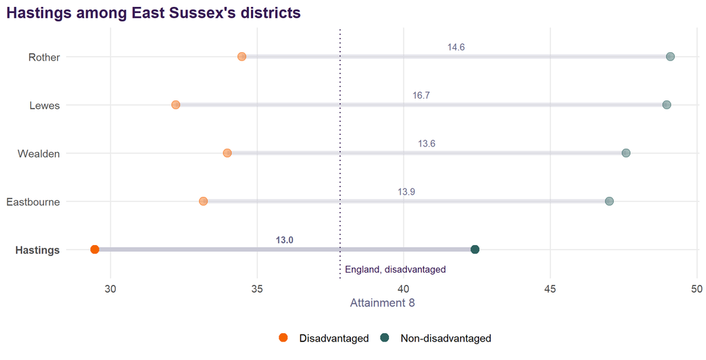

Figure 2: Attainment 8 for disadvantaged and non-disadvantaged pupils in East Sussex’s districts, 2024/25, school means. The gap between the two is printed on each district’s line; Hastings is in bold.

Across the years the model covers, the gap was 12.3 points in 2021/22 and 13.0 in 2024/25. Hastings’s non-disadvantaged pupils were above England’s average in 0 of 4 years, and its disadvantaged pupils in 0.

# 4 What explains attainment in Hastings

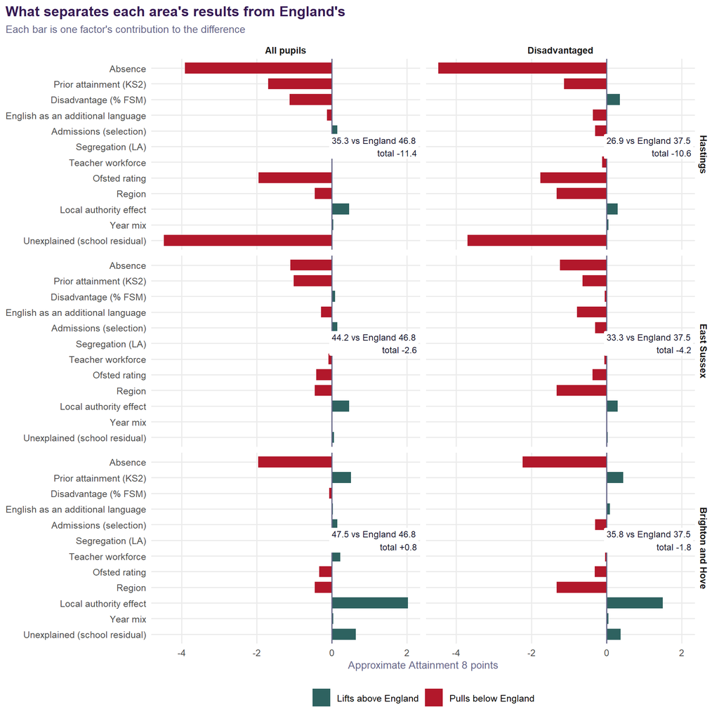

The decomposition for Hastings, in Attainment 8 points. ‘Place’ is East Sussex’s effect plus the South East’s; ‘unexplained’ is what the district’s own schools add beyond everything the model accounts for.

| Factor | All pupils | Disadvantaged | Non-disadvantaged |
| --- | --- | --- | --- |
| Unexplained (school residual) | -4.47 | -3.70 | -3.53 |
| Absence | -3.91 | -4.48 | -3.25 |
| Ofsted rating | -1.95 | -1.76 | -1.75 |
| Prior attainment (KS2) | -1.69 | -1.12 | -1.60 |
| Disadvantage (% FSM) | -1.12 | +0.36 | -0.52 |
| English as an additional language | -0.13 | -0.36 | -0.19 |
| Teacher workforce | -0.00 | -0.11 | -0.04 |
| Place (region and local authority) | -0.00 | -1.03 | +0.28 |
| Other model terms | +0.19 | -0.25 | +0.16 |

**For all pupils**, Hastings is 11.4 points below England. The pieces of at least a quarter of a point:

- absence (-3.91);
- Ofsted ratings (-1.95);
- prior attainment (-1.69);
- the level of disadvantage (-1.12);
- being in the South East (-0.46);
- East Sussex’s county-wide effect (+0.46);
- and the district’s schools themselves (-4.47), beyond what the model expects.

**For disadvantaged pupils**, Hastings is 10.6 points below England. The pieces of at least a quarter of a point:

- absence (-4.48);
- Ofsted ratings (-1.76);
- being in the South East (-1.32);
- prior attainment (-1.12);
- English as an additional language (-0.36);
- the level of disadvantage (+0.36);
- admissions (-0.30);
- East Sussex’s county-wide effect (+0.29);
- and the district’s schools themselves (-3.70), beyond what the model expects.

# 5 The disadvantaged gap, school by school

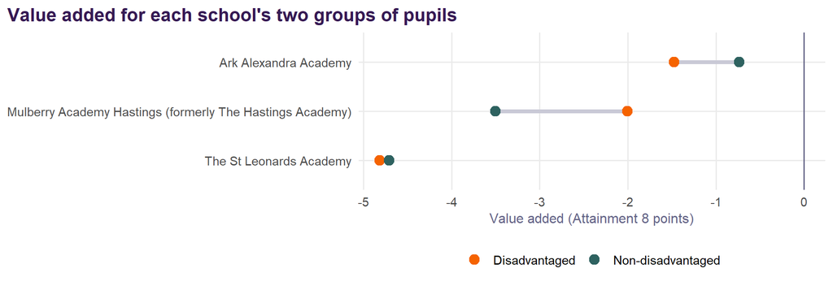

Figure 4: Each school’s value added for its disadvantaged and non-disadvantaged pupils, mean over the years available (2021/22 to provisional 2025/26). Above zero means better than the national model expects for similar pupils.

No Hastings school is above expectation for its non-disadvantaged pupils while more than a point below it for its disadvantaged ones.

The table below gives each school’s own persistent effect, from the model with a school term, which is the steadier measure.

Table 1: Each school’s own persistent effect on the national model with a school term (%), for each group of pupils and for absence beyond what its intake predicts. Positive absence is worse.

| School | All pupils | Disadvantaged | Non-disadvantaged | Absence (stage 1) |
| --- | --- | --- | --- | --- |
| The St Leonards Academy | -12.3 | -11.8 | -8.8 | +31.2 |
| The Hastings Academy | -7.5 | -3.7 | -4.8 | +35.2 |
| Ark Alexandra Academy | -2.7 | -3.0 | -0.1 | +5.2 |

Table 2: Attainment 8 of each school’s disadvantaged pupils, year by year (2025/26 provisional), with the size of the group in 2024/25. Small groups make single years unreliable.

| School | 2021/22 | 2022/23 | 2023/24 | 2024/25 | 2025/26 | Disadvantaged pupils, 2024/25 |
| --- | --- | --- | --- | --- | --- | --- |
| Ark Alexandra Academy | 32.7 | 29.1 | 26.8 | 34.3 | 36.3 | 71 |
| Mulberry Academy Hastings (formerly The Hastings Academy) | 30.6 | 24.4 | 25.3 | 28.4 | 33.8 | 50 |
| The St Leonards Academy | 23.9 | 20.8 | 24.0 | 25.7 | 30.8 | 101 |

# 6 Is there a Hastings effect?

The district test of the East Sussex document adds a district level to the national model, with and without each school’s own record.

Table 3: The Hastings district effect, over and above East Sussex’s, with 95% intervals.

| Specification | Outcome | Effect (%) | 95% interval | Significant |
| --- | --- | --- | --- | --- |
| Published specification | All pupils | -4.4 | -8.0 to -0.6 | Yes |
| Published specification | Disadvantaged | -3.9 | -8.1 to +0.5 | No |
| Published specification | Non-disadvantaged | -3.9 | -7.1 to -0.6 | Yes |
| Published specification | Absence (stage 1) | +9.9 | +1.4 to +19.0 | Yes |
| With a school term | All pupils | -1.6 | -5.0 to +1.9 | No |
| With a school term | Disadvantaged | -1.2 | -4.3 to +2.1 | No |
| With a school term | Non-disadvantaged | -2.2 | -5.8 to +1.4 | No |
| With a school term | Absence (stage 1) | +2.0 | -3.9 to +8.3 | No |

On the published model, Hastings differs from the rest of East Sussex for all pupils (-4.4%), non-disadvantaged pupils (-3.9%) and absence (+9.9%). With each school’s own record in the model, none of that remains: the difference belongs to particular schools, not to the district as a place.

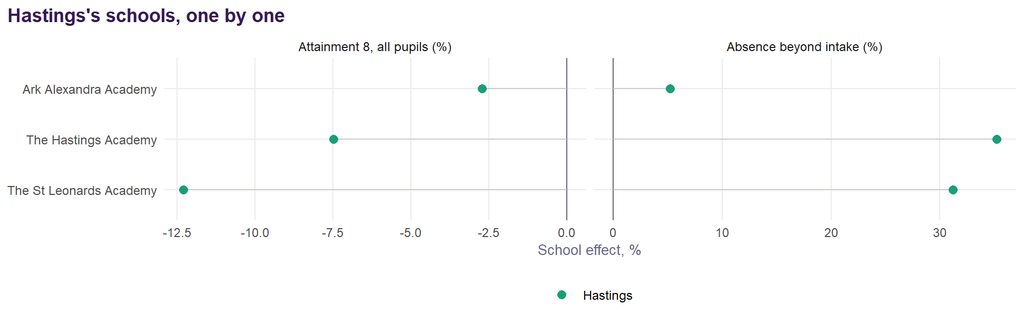

Figure 5: Each school’s own persistent effect, from the model with a school term: Attainment 8 for all pupils, and absence beyond what its intake predicts.